# Chinookのデータベースとの実験

Chinookのデータベースは、オンラインなソースから取り、オフラインなディスクで 保存した．特に音楽のトラックや客や販売についての情報である．データクリーニングは、 ここでしない．

要点は、このデジタル書の終にある．（「つまり」の名前がある見出しである．）

# 予備工作

構造は、次のイメージで見える．

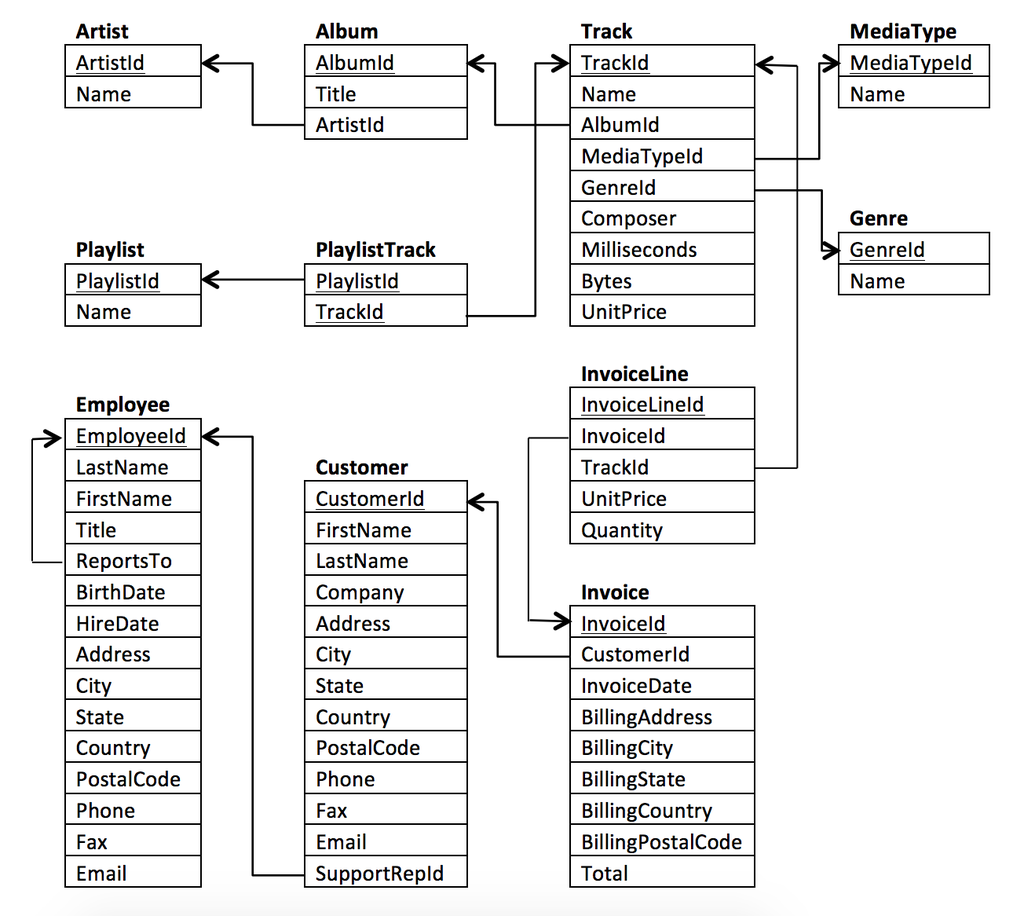

オンライン取られたこのイメージで見える用語は、データベースの為に精密ではない．データベースには、下線が時々使われるのである．しかし、この場合の為には、十分にいい．

## 通貨

通貨は、空想的な「M」である．

## ライブラリーとSQL

```r
library(data.table)
library(RPostgres)
library(rstudioapi)
#library(moments)
#library(lattice)  # 速い
library(ggplot2)
library(rnaturalearth) # 地理的なデータ
library(sf)
library(ggrepel)
library(patchwork) # 可視化の組み合わせむけのライブラリー
```

```r
con <- dbConnect(RPostgres::Postgres(),
                 host = 'localhost',
                 dbname = 'chinook',
                 user = 'postgres',
                 password = rstudioapi::askForPassword('Password')
)
```

# 質問

質問は、色々な可能性がある．例えば、違うジャンルのトラックの回数、芸術家についての質問、販売についての情報などの質問がある．

## 違うジャンルについての回数

ジャンルは、トラックが数えられる．

```r
genre_track_count <- dbGetQuery(con, '
    select g.genre_id, g.name as music_cat, count(*) as amount_of_tracks
    from genre g
    inner join track t on g.genre_id = t.genre_id
    group by g.genre_id, music_cat
    order by amount_of_tracks desc;
')

# data.tableがdata.frameやtibbleの代わりに欲しい
genre_track_count = as.data.table(genre_track_count)

# 率のカラムが加わる
genre_track_count[, percentage := amount_of_tracks / sum(amount_of_tracks) * 100]

# 見せる
genre_track_count
```

| genre_id | music_cat | amount_of_tracks | percentage |
| --- | --- | --- | --- |
| 1 | Rock | 1296 | 37.33794296 |
| 7 | Latin | 549 | 15.81676750 |
| 3 | Metal | 374 | 10.77499280 |
| 4 | Alternative & Punk | 332 | 9.56496687 |
| 2 | Jazz | 130 | 3.74531835 |
| 19 | TV Shows | 93 | 2.67934313 |
| 6 | Blues | 81 | 2.33362143 |
| 24 | Classical | 74 | 2.13195045 |
| 21 | Drama | 64 | 1.84384903 |
| 14 | R&B/Soul | 61 | 1.75741861 |

[output cut: 15 more lines]

その結果によると、最初の５つは、ロック、ラテン音楽、メタル、オールターナティヴとパンク、とジャズである．

### 可視化

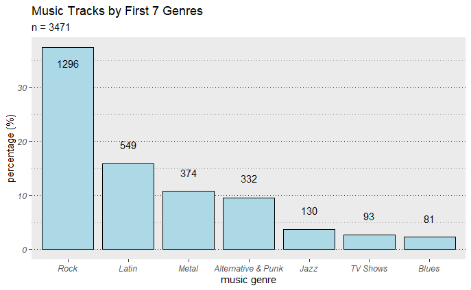

```r
# 第一の７つの可視化
genre_track_count_p <-
 ggplot(genre_track_count[1:7, ], aes(reorder(music_cat, -percentage),
                                     percentage)) +
    geom_col(color='black', fill='lightblue', width=0.85) +
    xlab('music genre') +
    ylab('percentage (%)') +
    labs(title='Music Tracks by First 7 Genres',
         subtitle='n = 3471') +
    theme(panel.grid.major.x=element_blank()) +
    theme(panel.grid.major.x=element_blank()) +
    theme(panel.grid.minor.y=element_line(color='darkgrey', linetype='dotted')) +
    theme(panel.grid.major.y=element_line(color='black', linetype='dotted')) +
    theme(axis.text=element_text(face='italic')) +
    annotate('text', x='Rock', y=34.5, label='1296') +
    annotate('text', x='Latin', y=19.35, label='549') +
    annotate('text', x='Metal', y=14.2, label='374') +
    annotate('text', x='Alternative & Punk', y=13.2, label='332') +
    annotate('text', x='Jazz', y=7.2, label='130') +
    annotate('text', x='TV Shows', y=6.2, label='93') +
    annotate('text', x='Blues', y=5.7, label='81')

genre_track_count_p
```

## メディア類

メディア類は、少し調べる．

```r
dbGetQuery(con, '
    select * from media_type;
')
```

| media_type_id | name |
| --- | --- |
| 1 | MPEG audio file |
| 2 | Protected AAC audio file |
| 3 | Protected MPEG-4 video file |
| 4 | Purchased AAC audio file |
| 5 | AAC audio file |

この場合は、直接的にメディア類と総数が見つかった．

### 数える事と可視化

ここでは、数えられる．

```r
# データをdata.frameに置く
mediatypes_count_df <- dbGetQuery(con, '
    select mt.name, count(*) as track_count
    from media_type mt
    inner join track tr on mt.media_type_id = tr.media_type_id
    group by mt.name
    order by track_count desc;
')

# data.tableに変え、率のカラムを足し、種類の用語を短くし、表を見せる
mediatypes_count_df = as.data.table(mediatypes_count_df)
mediatypes_count_df[, percentage := track_count / sum(track_count) * 100]
mediatypes_count_df$name = gsub(' file', '', mediatypes_count_df$name)
mediatypes_count_df
```

| name | track_count | percentage |
| --- | --- | --- |
| MPEG audio | 3002 | 86.4880438 |
| Protected AAC audio | 237 | 6.8280035 |
| Protected MPEG-4 video | 214 | 6.1653702 |
| AAC audio | 11 | 0.3169116 |
| Purchased AAC audio | 7 | 0.2016710 |

そのテーブルは、十分に明らかであるものの、発揮のために可視化する．

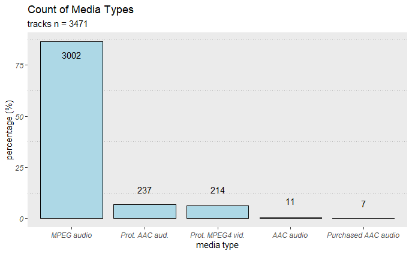

```r
# ２つの名前が変わるようにする
mediatypes_count_df__ <- mediatypes_count_df
mediatypes_count_df__[2,1] = 'Prot. AAC aud.'
mediatypes_count_df__[3,1] = 'Prot. MPEG4 vid.'

# 可視化
mediatypes_count_df__p <-
 ggplot(data=mediatypes_count_df__, aes(reorder(name,-percentage), percentage))+
    labs(title='Count of Media Types',
         subtitle='tracks n = 3471') +
    ylab('percentage (%)') +
    xlab('media type') +
    geom_col(color='black', fill='lightblue', width=0.85) +
    theme(panel.grid.major=element_blank()) +
    theme(axis.text=element_text(face='italic')) +
    theme(panel.grid.minor.y=element_line(color='darkgrey', linetype='dotted')) +
    annotate('text', x='MPEG audio', y=80, label='3002') +
    annotate('text', x='Prot. AAC aud.',y=14.2, label='237') +
    annotate('text', x='Prot. MPEG4 vid.', y=14.15, label='214') +
    annotate('text', x='AAC audio', y=8.5, label='11') +
    annotate('text', x='Purchased AAC audio', y=7.5, label='7')

mediatypes_count_df__p
```

テーブルで明らかであるように、８割以上のMPEGオーディオファイルが大変明らかに 第一のメディア類である．Protected AACオーディオも、Protected MPEG-4オーディオも、約６％である．そうらなば、AACオーディオとPurchased AACオーディオの項目を見るのが欲しい．

### AACオーディオ

```r
# AACオーディオのトラック
dbGetQuery(con, '
    select
       tr.name as track_title,
       g.name as genre,
       tr.composer
    from track tr
    inner join media_type mt on tr.media_type_id = mt.media_type_id
    inner join genre g on tr.genre_id = g.genre_id
    where mt.media_type_id = 5;
')
```

| track_title | genre | composer |
| --- | --- | --- |
| Amanda | Jazz | Luca Gusella |
| Despertar | Jazz | Andrea Dulbecco |
| Din Din Wo (Little Child) | World | Habib Koité |
| Distance | Electronica/Dance | Karsh Kale/Vishal Vaid |
| I Guess You're Right | Rock | Darius "Take One" Minwalla/Jon Auer/Ken Stringfellow/Matt Harris |
| I Ka Barra (Your Work) | World | Habib Koité |
| Love Comes | Rock | Darius "Take One" Minwalla/Jon Auer/Ken Stringfellow/Matt Harris |
| Muita Bobeira | Latin | Luciana Souza |
| OAM's Blues | Jazz | Aaron Goldberg |
| One Step Beyond | Electronica/Dance | Karsh Kale |

[output cut: 1 more lines]

僕は、その音楽をだいたい知っていないであろうと思う．おまけに、クラシックな音楽が欲しい ものの、Beethovenずきではない．（さらには、文字の中に文字化けがあるが、そんな事は このデジタル書の目的ではない．）

### Purchased AACオーディオ

```r
# Purchased AACオーディオのトラック
dbGetQuery(con, '
    select
       tr.name as track_title,
       g.name as genre,
       tr.composer
    from track tr
    inner join media_type mt on tr.media_type_id = mt.media_type_id
    inner join genre g on tr.genre_id = g.genre_id
    where mt.media_type_id = 4;
')
```

| track_title | genre | composer |
| --- | --- | --- |
| War Pigs | Alternative | NA |
| Concerto for Violin, Strings and Continuo in G Major, Op. 3, No. 9: I. Allegro | Classical | Pietro Antonio Locatelli |
| Étude 1, In C Major - Preludio (Presto) - Liszt | Classical | NA |
| Sonata for Solo Violin: IV: Presto | Classical | Béla Bartók |
| Prometheus Overture, Op. 43 | Classical | Ludwig van Beethoven |
| SCRIABIN: Prelude in B Major, Op. 11, No. 11 | Classical | NA |
| Symphony No. 104 in D Major "London": IV. Finale: Spiritoso | Classical | Franz Joseph Haydn |

その方は、僕にとっていい．クラシックな音楽なのである．Scriabinが興味深い作曲家である． Bela Bartokの音楽は、もう忘れたが、Bartokずきではなかった．データは、 もう一遍、残念ながら、少なくとも二つの文字列が悪い． ３番目の項目と４番目のである．さらに、作曲家の列に３つの項目が欠いている． （このデジタルな書は、そんな事を扱うのが目的ではない．）

## アーティスト

### アーティストのテーブル

アーティストのテーブルは、他のあらゆるテーブルのようにidの安全もあり、何が数である ことを調べられる．

```r
dbGetQuery(con, '
    select count(*) from artist;
')
```

| count |
| --- |
| 275 |

### アルバムのテーブル

アルバムの数は、何であるか．

```r
dbGetQuery(con, '
    select count(*) from album;
')
```

| count |
| --- |
| 345 |

### アーティストとアルバム

アーティストによりアルバムの総数を取り、25つ目まで置く．

```r
artist_album_count <- dbGetQuery(con, '
    select ar.artist_id, ar.name, count(*) as album_count
    from artist ar
    inner join album al on ar.artist_id = al.artist_id
    group by ar.artist_id
    order by album_count desc
    limit 25;
')
artist_album_count = as.data.table(artist_album_count)
artist_album_count
```

| artist_id | name | album_count |
| --- | --- | --- |
| 90 | Iron Maiden | 21 |
| 22 | Led Zeppelin | 14 |
| 58 | Deep Purple | 11 |
| 150 | U2 | 10 |
| 50 | Metallica | 10 |
| 114 | Ozzy Osbourne | 6 |
| 118 | Pearl Jam | 5 |
| 21 | Various Artists | 4 |
| 82 | Faith No More | 4 |
| 152 | Van Halen | 4 |

[output cut: 15 more lines]

しかし、アーティストの販売については、情報を引く．少なくとも400M分のトラックをChinookで売ったアーティストは、表を引く．

```r
artist_sales = dbGetQuery(con, '
    select ar.name as artistname, sum(inv.total)
    from artist ar
    inner join album al on ar.artist_id = al.artist_id
    inner join track tr on al.album_id = tr.album_id
    inner join invoice_line invl on tr.track_id = invl.track_id
    inner join invoice inv on invl.invoice_id = inv.invoice_id
    group by artistname
    having sum(inv.total) >= 400
    order by sum(inv.total) desc;
')
artist_sales = as.data.table(artist_sales)
artist_sales
```

| artistname | sum |
| --- | --- |
| Iron Maiden | 1233.54 |
| U2 | 895.59 |
| Lost | 833.70 |
| Led Zeppelin | 620.73 |
| Metallica | 599.94 |
| Deep Purple | 550.44 |
| Pearl Jam | 408.87 |

トラックを４００M分売った７つのアーティストの団がいるし、Iron Maidenが１位がある．

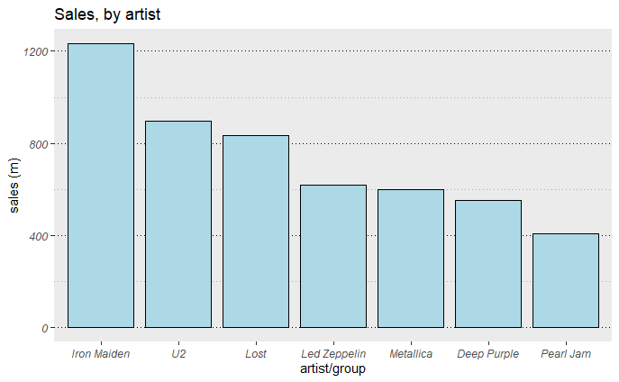

```r
# 可視化
artist_sales_p <- ggplot(data=artist_sales, aes(reorder(artistname, -sum), sum)) +
    geom_col(color='black', fill='lightblue', width=0.85) +
    labs(title='Sales, by artist') +
    ylab('sales (m)') +
    xlab('artist/group') +
    theme(panel.grid.major.x=element_blank()) +
    theme(panel.grid.major.y=element_line(color='black', linetype='dotted')) +
    theme(panel.grid.minor.y=element_line(color='darkgrey', linetype='dotted')) +
    theme(axis.text=element_text(face='italic'))

artist_sales_p
```

## お客様

### お客様の回数

お客様は、まず総数が見つかる．お客様の表はもちろん他のテーブルのように唯一の列である．

```r
dbGetQuery(con, '
    select count(*) from customer;
')
```

| count |
| --- |
| 59 |

### 一番高い回数の国

```r
dbGetQuery(con, '
    select c.country, count(*) as customer_count
    from customer c
    group by c.country
    order by count(*) desc
    limit 1;
')
```

| country | customer_count |
| --- | --- |
| USA | 13 |

お客様の回数は、国により米国である．

```r
(13/59)
```

```
[1] 0.220339
```

約２２％である．しかし、もっと大きい表が欲しい．

### 国によりお客様の回数

```r
customer_count_by_country <- dbGetQuery(con, '
    select c.country, count(*) as customer_count
    from customer c
    group by c.country
    order by customer_count desc;
')
customer_count_by_country = as.data.table(customer_count_by_country)
customer_count_by_country[, percentage := customer_count/sum(customer_count)
                          * 100]
customer_count_by_country
```

| country | customer_count | percentage |
| --- | --- | --- |
| USA | 13 | 22.033898 |
| Canada | 8 | 13.559322 |
| France | 5 | 8.474576 |
| Brazil | 5 | 8.474576 |
| Germany | 4 | 6.779661 |
| United Kingdom | 3 | 5.084746 |
| Portugal | 2 | 3.389831 |
| India | 2 | 3.389831 |
| Czech Republic | 2 | 3.389831 |
| Norway | 1 | 1.694915 |

[output cut: 14 more lines]

お客様がいらっしゃる国々は、２４ヶ国である．

```r
# Natural Earthの地理的なデータを取り、保存する
chikyuuzu <- ne_countries(scale='medium', returnclass='sf')
```

```r
# customer_count_by_countryのデータをchikyuuzuのテーブルに足す
# しかし、まずは、国の数名前を変化しなくてはいけない
customer_count_by_country$country = gsub('USA', 'United States', customer_count_by_country$country)
customer_count_by_country$country = gsub('Czech Republic', 'Czech Rep.', customer_count_by_country$country)

# ここでは、ついにデータを足し、chikyuuzuのあらゆる国を保つ
atarashii_chikyuuzu <-merge(chikyuuzu, customer_count_by_country, by.x='name', by.y='country', all=T)

# atarashii_chikyuuzuのcustumor_countの列は、ヌル値があり、replace()で
# 退けたかったが、結局はそうしなかった．
```

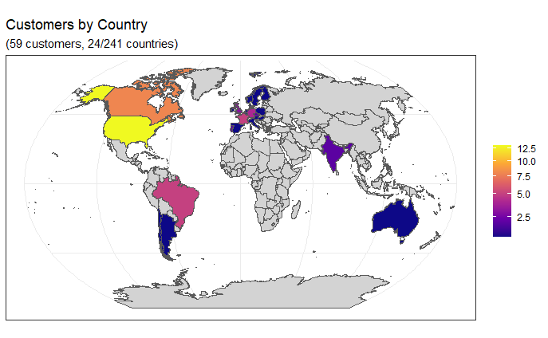

```r
# 可視化
customer_count_by_country_p <- ggplot(atarashii_chikyuuzu) +
    theme_bw() +
    geom_sf(aes(fill=customer_count)) +
    scale_fill_viridis_c(option='plasma', trans='sqrt', na.value='lightgrey') +
    coord_sf(crs='+proj=kav7') +   # Winkel Tripel図法が欲しかったが、迷惑すぎた
    labs(title='Customers by Country', subtitle='(59 customers, 24/241 countries)') +
    theme(legend.title=element_blank())

customer_count_by_country_europe_p <- ggplot(atarashii_chikyuuzu) +
    theme_bw() +
    geom_sf(aes(fill=customer_count)) +
    scale_fill_viridis_c(option='plasma', trans='sqrt', na.value='lightgrey') +
    coord_sf(xlim=c(-20, 40), ylim=c(36.5, 79)) +
    theme(legend.position='none') +
    theme(axis.text=element_blank()) +
    theme(axis.ticks=element_blank()) +
    theme(panel.grid=element_blank())

customer_count_by_country_southamerica_p <- ggplot(atarashii_chikyuuzu) +
    theme_bw() +
    geom_sf(aes(fill=customer_count)) +
    scale_fill_viridis_c(option='plasma', trans='sqrt', na.value='lightgrey') +
    coord_sf(xlim=c(-90, -30), ylim=c(-60, 30)) +
    theme(legend.position='none') +
    theme(axis.text=element_blank()) +
    theme(axis.ticks=element_blank()) +
    theme(panel.grid=element_blank())

customer_count_by_country_india_p <- ggplot(atarashii_chikyuuzu) +
    theme_bw() +
    geom_sf(aes(fill=customer_count)) +
    scale_fill_viridis_c(option='plasma', trans='sqrt', na.value='lightgrey') +
    coord_sf(xlim=c(65, 100), ylim=c(5, 35)) +
    theme(legend.position='none') +
    theme(axis.text=element_blank()) +
    theme(axis.ticks=element_blank()) +
    theme(panel.grid=element_blank())

customer_count_by_country_oceania_p <- ggplot(atarashii_chikyuuzu) +
    theme_bw() +
    geom_sf(aes(fill=customer_count)) +
    scale_fill_viridis_c(option='plasma', trans='sqrt', na.value='lightgrey') +
    coord_sf(xlim=c(100, 180), ylim=c(-50, 0)) +
    theme(legend.position='none') +
    theme(axis.text=element_blank()) +
    theme(axis.ticks=element_blank()) +
    theme(panel.grid=element_blank())

customer_count_by_country_p
```

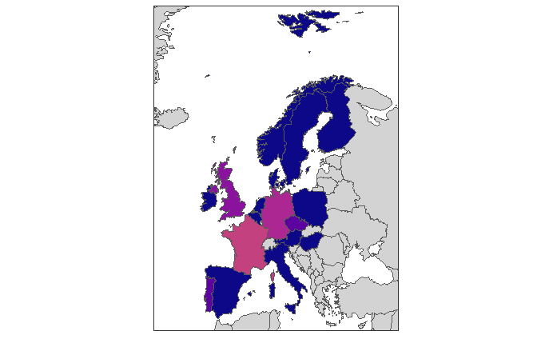

```r
customer_count_by_country_europe_p
```

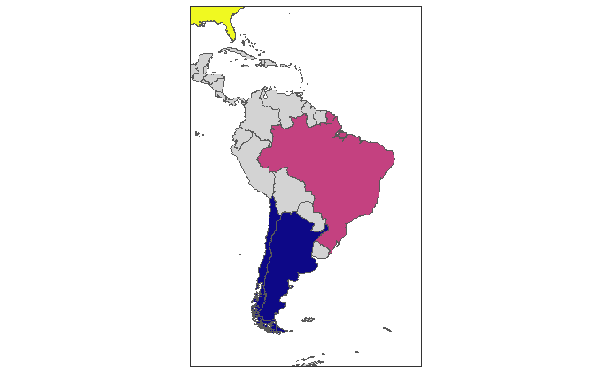

```r
customer_count_by_country_southamerica_p
```

```r
#customer_count_by_country_india_p
#customer_count_by_country_oceania_p
```

## 売上（もう一回）

### ジャンルにより売り上げ

売上上は、ジャンルの中でどれが最高であるか．

```r
sales_by_genre <- dbGetQuery(con, '
    select g.name as genre_, sum(invoice.total) as sold_in_M
    from genre g
    inner join track tr on g.genre_id = tr.genre_id
    inner join invoice_line on tr.track_id = invoice_line.track_id
    inner join invoice on invoice_line.invoice_id = invoice.invoice_id
    group by genre_
    order by sold_in_M desc;
')
sales_by_genre = as.data.table(sales_by_genre)
sales_by_genre[, percentage := sold_in_m / sum(sold_in_m) * 100]
sales_by_genre[, percentage := round(percentage, digits=2)]
sales_by_genre
```

| genre_ | sold_in_m | percentage |
| --- | --- | --- |
| Rock | 7706.16 | 37.36 |
| Latin | 3263.66 | 15.82 |
| Metal | 2093.13 | 10.15 |
| Alternative & Punk | 1961.66 | 9.51 |
| TV Shows | 817.71 | 3.96 |
| Jazz | 746.46 | 3.62 |
| Drama | 544.61 | 2.64 |
| Blues | 429.66 | 2.08 |
| R&B/Soul | 338.62 | 1.64 |
| Reggae | 332.64 | 1.61 |

[output cut: 14 more lines]

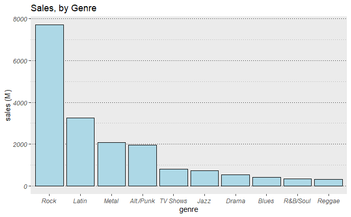

```r
# 'Alternative & Punkは名前が長すぎる'
sales_by_genre__ <- sales_by_genre
sales_by_genre__[4, 1] = 'Alt./Punk'

# 可視化
sales_by_genre__p <-
 ggplot(data=sales_by_genre__[1:10,], aes(reorder(genre_,-sold_in_m), sold_in_m)) +
    labs(title='Sales, by Genre') +
    xlab('genre') +
    ylab('sales (M)') +
    geom_col(color='black', fill='lightblue') +
    theme(panel.grid.major.x=element_blank()) +
    theme(axis.text=element_text(face='italic')) +
    theme(panel.grid.major.y=element_line(color='black', linetype='dotted')) +
    theme(panel.grid.minor.y=element_line(color='darkgrey', linetype='dotted'))

sales_by_genre__p
```

### 従業員により売上

```r
sales_by_employee <- dbGetQuery(con, '
    select
        e.employee_id,
        e.title,
        e.last_name,
        e.first_name,
        sum(inv.total) as total_sales
    from employee e
    inner join customer c on e.employee_id=c.support_rep_id
    inner join invoice inv on c.customer_id=inv.customer_id
    group by e.employee_id
    order by total_sales desc
    ;
')
sales_by_employee = as.data.table(sales_by_employee)
sales_by_employee
```

| employee_id | title | last_name | first_name | total_sales |
| --- | --- | --- | --- | --- |
| 3 | Sales Support Agent | Peacock | Jane | 833.04 |
| 4 | Sales Support Agent | Park | Margaret | 775.40 |
| 5 | Sales Support Agent | Johnson | Steve | 720.16 |

この場合は、その表によると、３人のみ直接的にセールする．従業員のテーブルをもっと 調べた方がいい．

```r
# 数える
dbGetQuery(con, '
    select count(*) as employee_count
    from employee
')
```

| employee_count |
| --- |
| 8 |

そして横であるあらゆる列が見える．

```r
# テーブルの部分
dbGetQuery(con, '
select
   e.employee_id,
   e.title,
   e.last_name,
   e.first_name,
   e.reports_to
from employee e
;
')
```

| employee_id | title | last_name | first_name | reports_to |
| --- | --- | --- | --- | --- |
| 1 | General Manager | Adams | Andrew | NA |
| 2 | Sales Manager | Edwards | Nancy | 1 |
| 3 | Sales Support Agent | Peacock | Jane | 2 |
| 4 | Sales Support Agent | Park | Margaret | 2 |
| 5 | Sales Support Agent | Johnson | Steve | 2 |
| 6 | IT Manager | Mitchell | Michael | 1 |
| 7 | IT Staff | King | Robert | 6 |
| 8 | IT Staff | Callahan | Laura | 6 |

## つまり

結論は、Chinookのデータベースは、小さくて、会社は小さくて８人の従業員がいる． 従業員は、1人が総支配人であり、1人が販売の課長であり、1人がITの課長であり、 販売部の課長の下には３人の販売員がいて、IT部の課長の下には２人がいる．

メディア類は、５つがあり、約８６％の率があり３００２つのトラックがあるMPEG Audio が最高である．他のメディア類は、Protected AAC AudioとProtected MPEG-4 Videoが 少なくとも２００つであり、AAC AudioとPurchased AAC Audioはほとんどない．

ジャンルは、トラックの回数は、３４７１つの全体の中でロックと、ラテン音楽と、 メタルがトップであり、ロックは３７％があることで特にトップにある． ラテン音楽はほぼ１６％であり、メタルはほぼ１１％である．Alternative and Punkが４番目であり、ほぼ１割である．売上点では、その４つの順番が同じであり、 ロックでほぼ８０００Mが取られ、ラテン音楽でほぼ３２００Mが取られ、 メタルで約２１００Mが取られ、Alternative and Punkでほぼ２０００Mが取られた．

販売員は、Peacock Janeさんが最高を売っている．

アーティスト面では、Iron Maidenと、U2と、Lostと、Led Zeppelinと、Metallicaと、 Deep Purpleと、Pearl Jamで特に多くのＭが取られている．Iron Maidenが一位がある． 述べられたこのアーティストは、ロックバンドである．多くのアルバムがあるバンドは、 Iron Maidenと、Led Zeppelinと、Deep Purpleと、U2と、Metallicaこそである．

お客様は、５９人であり、米国にこそいる（すなわち、１３人、２２％）．

### 多プロット

```r
# 簡単なテーブル
artist_and_album_count_etc <- data.table(
    x = c('artists', 'albums', 'employees', 'customers', 'tracks', 'served countries'),
    count = c(275, 345, 8, 59, 3471, 24)
)

# 可視化
artist_and_album_count_etc_p <- ggplot(artist_and_album_count_etc,
                                       aes(x=reorder(x, -count), y=count)) +
    geom_col(color='black', fill='lightblue') +
    labs(title='Overall Counts') +
    xlab(element_blank()) +
    theme(panel.grid.major.x=element_blank()) +
    theme(panel.grid.major.y=element_line(color='black', linetype='dotted')) +
    theme(panel.grid.minor.y=element_line(color='darkgrey', linetype='dotted')) +
    theme(axis.text=element_text(face='italic')) +
    annotate('text', x='albums', y=470, label='345') +
    annotate('text', x='employees', y=100, label='8') +
    annotate('text', x='customers', y=184, label='59') +
    annotate('text', x='served countries', y=150, label='24') +
    annotate('text', x='artists', y=400, label='275')
```

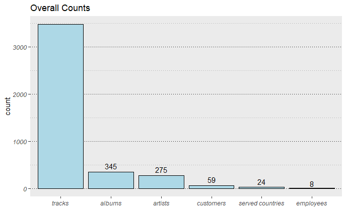

```r
artist_and_album_count_etc_p;
```

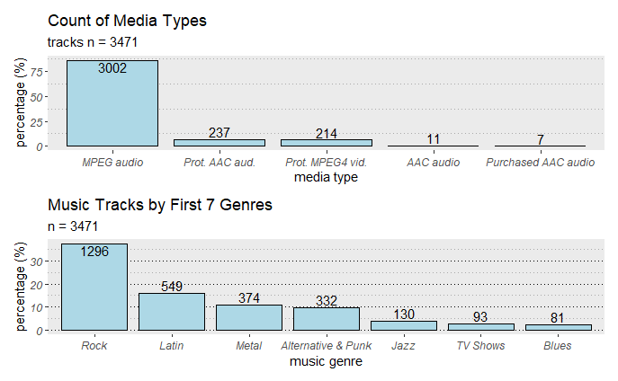

```r
(mediatypes_count_df__p / genre_track_count_p);
```

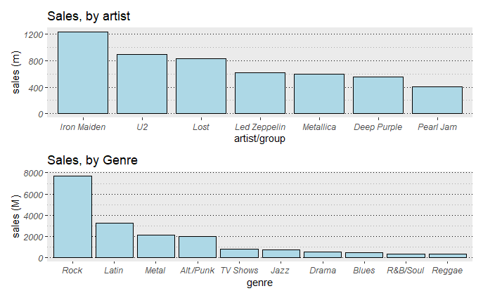

```r
artist_sales_p / sales_by_genre__p;
```

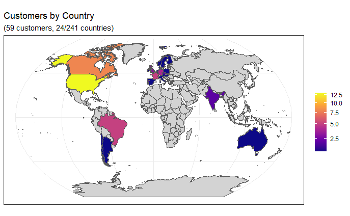

```r
customer_count_by_country_p;
```

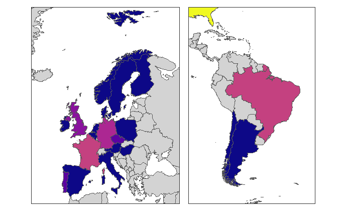

```r
customer_count_by_country_europe_p + customer_count_by_country_southamerica_p
```